# Heat3d

A study on 3D-printed heatmaps

Tyler Wiederich

University of Nebraska-Lincoln

April 7, 2025

## Study participation

Before we begin, please access https://shiny.srvanderplas.com/heat3d/ to participate in the pilot study!

# Methodology

## Goal

The goal of this experiment is to see how well participants estimate values across three chart types.

- 2D-digital (2dd)
- 3D-digital (3dd)
- 3D-printed (3dp)

## Stimuli Creation

We use the method of constant stimuli for creating our stimuli.

$$S=\text{Stimuli}$$

- All values are between 0 and 100
- The constant is 50
- The largest value is 90
- All other values between 50 and 90 are created such that the ratios between 0.556 and 1 are equally spaced
- Values between 0 and 50 are chosen such that the same ratios as above are used

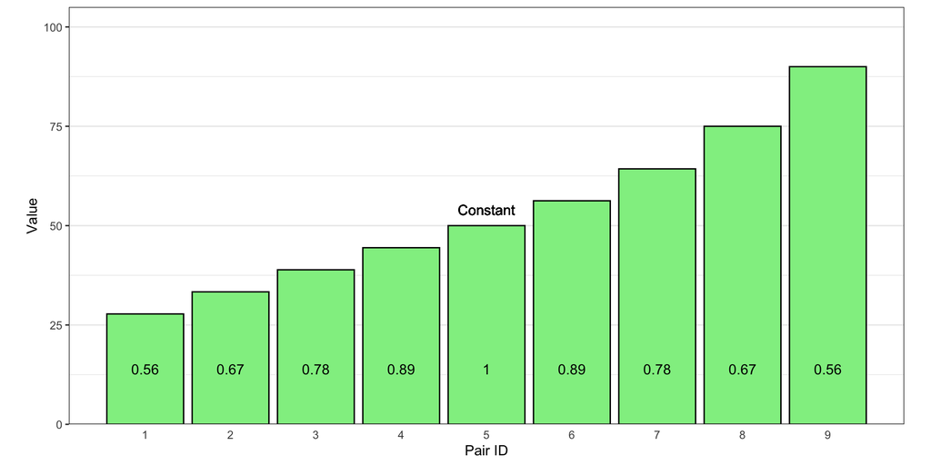

## Generating Heatmap Data

The general shape of the heatmap is a mixture distribution between mathematical formula and uniform random noise.

$$Z=0.3\cdot U(0,100) + 0.7\cdot f(X,Y)$$

where $f(X,Y)$ is any given function, scaled between 0 and 100

- Top half of a sphere centered at 5.5
- Lower half of a sphere centered at 5.5

## Stimuli Placement

1. Data is simulated from previous function to generate grid $(X=1\dots 10, Y=1\dots 10)$
2. Non-50 value is placed onto grid coordinate that minimizes $|Z-S|$
3. 50 is placed similarly, but only on coordinates that have a Manhattan distance of 3 or 4

$$|X_1-X_2|+|Y_1-Y_2| = 3 \text{ or } 4$$

4. Repeat process 20 times for a list of heatmaps
5. Use Chi-squared tests to find heatmaps where stimuli are somewhat equally spaced

## Heatmap selection

With 9 pairs of values, it is expected to see 1.8 stimuli values in each row/column of the heatmap.

| Grid Position | 1 | 2 | 3 | 4 | 5 | 6 | 7 | 8 | 9 | 10 |
| --- | --- | --- | --- | --- | --- | --- | --- | --- | --- | --- |
| Expected | 1.8 | 1.8 | 1.8 | 1.8 | 1.8 | 1.8 | 1.8 | 1.8 | 1.8 | 1.8 |
| Observed | $n_1$ | $n_2$ | $n_3$ | $n_4$ | $n_5$ | $n_6$ | $n_7$ | $n_8$ | $n_9$ | $n_{10}$ |

$$\chi^2=\sum\frac{(\text{Observed}-\text{Expected})^2}{\text{Expected}}$$

We use the grid with the smallest average $\chi^2$ for the $X$ and $Y$ axes.

# Study Design

## Study Design

For a full replicate, there are $3\times2\times9=54$ treatment combinations:

- 3 media types (2dd, 3dd, 3dp)
- 2 datasets
- 9 pairs of stimuli

Way too many trials for a single participant’s attention span!

[figure not shown]

## Incomplete Block

Our main interest is the difference between media types, measured at a given ratio and dataset. To accomplish this and to reduce the number of trials per participant, we use 4 of the 9 possible stimuli pairs to create blocks.

$$2\times3\times4=24$$

## Experiment

1. Ask participants which value in a stimuli pair is larger
2. Ask participants to estimate the value of the smaller stimuli
3. After each dataset and media combination, ask participant to rate their level of confidence

## Population

This study will be used in STAT 218 courses at UNL as a required project.

- Students who are at least 19 years old and consent to data collection

Students will also complete a series of reflections.

- Pre-experiment
- Post-experiment
- Abstract / paper
- Video presentation

## Other considerations

Type of responses

- Difference between stimuli and participant response
  - Cleveland and McGill (1984) used $\log_2(\text{Error}+1/8)$

Construction of Media

- How to most similarly construct stimuli so that we can accurately estimate the differences between media types?
  - Color scales for 2dd
  - STL colors for 3dd vs. filament colors for 3dp

# Thank you!

[figure not shown]